# about

asbates

2021-07-03

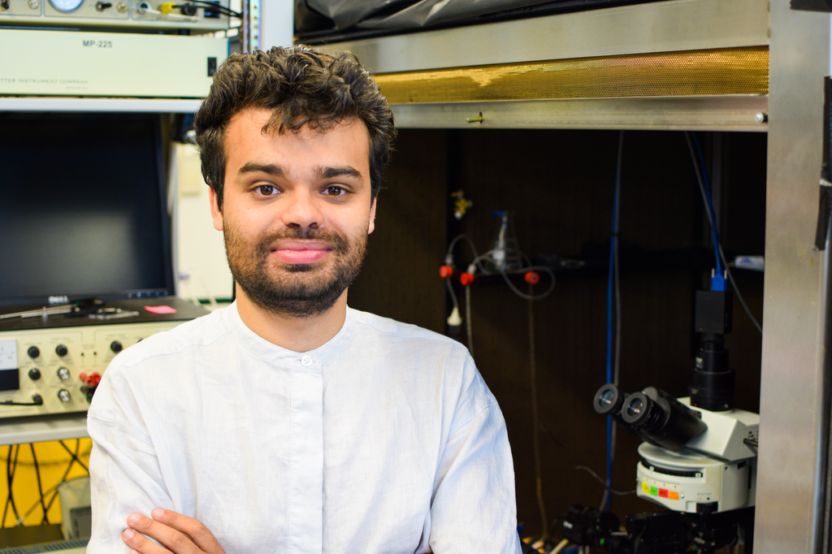

| total_cites | h_index | i10_index |
| --- | --- | --- |
| 5178 | 23 | 26 |

> “INSECTS possess a nervous system that is incredibly complex and differentiated, and whose sophistication attains ultramicroscopic levels … Certainly, the grey substance [of the brain of vertebrates] has increased considerably in mass, but when one compares its structure with that of the brain of Apidae or Libellulidae, it looks as excessively coarse and rudimentary. It is like pretending to match the rough merit of a standing wall clock with that of a pocket watch, a marvel of delicacy and precision. As usually, the genius of life shines more in the construction of smaller than larger master pieces.” ([SR y Cajal](https://www.britannica.com/biography/Santiago-Ramon-y-Cajal))

[I am a neuroscientist](https://scholar.google.com/citations?user=BOVTiXIAAAAJ&hl=en) studying the neurobiology of animal navigation in the [Wilson lab](https://wilson.hms.harvard.edu/) at [Harvard Medical School](https://hms.harvard.edu/) since March 2021. The animal I study is the vinegar fly, *Drosophila melanogaster*. I used to build connectomics tools and analyses for synaptic-resolution data sets for this little fly in my previous life as [University of Cambridge](https://www.cam.ac.uk/) PhD student at the [MRC LMB](https://www2.mrc-lmb.cam.ac.uk/), in the group of [Greg Jefferis](https://en.wikipedia.org/wiki/Gregory_Jefferis), and still do sometimes. I have a whole [thesis](https://t.co/TzCi2OPViD?amp=1) on the matter. I have also lead a scientific student magazine, [BlueSci](https://www.bluesci.co.uk/), and once hoped to be an author of something other than [scientific papers](https://scholar.google.com/citations?view_op=list_mandates&hl=en&user=BOVTiXIAAAAJ&tzom=240); I still hope that a bit.

[figure not shown]

I am interested in the structure of small brains. I think that we will be able to learn more about how a nervous system can control its flesh bot from tiny things, than we will from bigger things like mammals. At the moment, I am interested in trying to make in roads starting from the connectomes our field has striven to hard to build. Right now, this means I am trying to interpret navigational circuitry and predict what it does, testing these predictions using a course of behavioural and physiological experimentation. I aim to manipulate and record single cell types from the connectome - single nodes on the grand connectomic graph - while flies are stable and behaving in virtual reality.

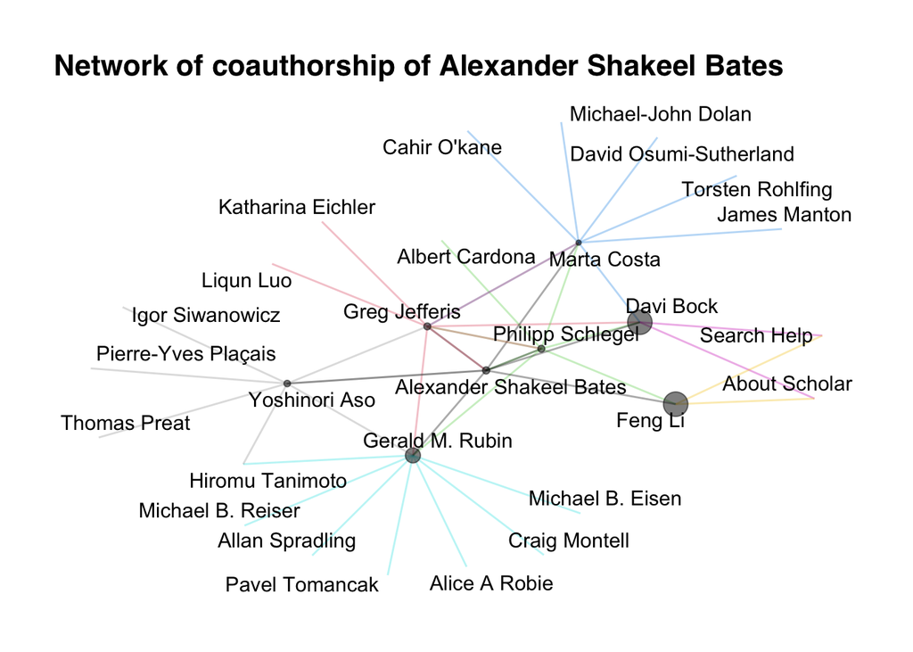

Right now, I am just getting started. The first tasks is to set-up virtual reality environments, get the flies behaving properly and start manipulating some neurons I think are involved in prescribing how they navigate.